IE 360 - HW 1 Hamza Kale April 15, 2022

# 1 Introduction

In this homework, I would like to understand what influences the Housing Unit Prices. To succeed that I choose the research question which is whether the Housing Unit Prices are related to the Price Indices, and/or Interest Rates For Banks Loans or not.

Data: 2010-01,2021-12 (Monthly) Data categories from EVDS: HOUSING AND CONSTRUCTION STATISTICS Housing Unit Prices(Monthly) Housing Unit Prices for Turkey - TL/sq m PRICE INDICES Cost of Living Indices for Wage Earners Dwelling Expenses (ICC 1995=100) INTEREST RATES Weighted Average Interest Rates For Banks Loans (Flow Data, %))(Monthly) Housing (TRY)(Flow Data, %)

# 2) Preparing data

## 2.1) Loading the required packages:

```r
library("readxl")
library("ggplot2")
library("usethis")
library("devtools")
library("scales")
library("zoo")
```

## 2.2) Merging Data

After I get the datasets from EVDS database in .xlsx format, I converted the all dates to the standard format. Then I combine them under a data frame which name is alldata to make easier to do data to visualize data.

```r
konutinterest<-read_excel("deneme2.xlsx")
konutinterest$Dates<-paste0(konutinterest$Dates, rep("-15",length(konutinterest$Dates)))
konutinterest$Dates<-as.Date(konutinterest$Dates)



konutfiyat<-read_excel("deneme2.2.xlsx")
konutfiyat$Dates<-paste0(konutfiyat$Dates, rep("-15",length(konutfiyat$Dates)))
konutfiyat$Dates<-as.Date(konutfiyat$Dates)



konutkredi<-read_excel("denemegoogle.xlsx")
konutkredi$Dates<-paste0(konutkredi$Dates, rep("-15",length(konutkredi$Dates)))
konutkredi$Dates<-as.Date(konutkredi$Dates)

dwellingexpenses<-read_excel("CostofLivingIndicesforWageEarners.xlsx")
dwellingexpenses$Dates<-paste0(dwellingexpenses$Dates, rep("-15",length(dwellingexpenses$Dates)))
dwellingexpenses$Dates<-as.Date(dwellingexpenses$Dates)



alldata<-data.frame(cbind(konutfiyat$Dates,konutfiyat$konutfiyat,konutinterest$konutinterest,konutkredi$konutkredi,dwellingexpenses$dwellingexpenses))
alldata$X1<-as.Date(alldata$X1)

colnames(alldata)<-c("Dates","konutfiyat", "konutinterest","konutkredi","dwellingexpenses")
```

# 3) Visualizing the Datasets & Correlations

## 3.1) The Price of Unit House in Turkey

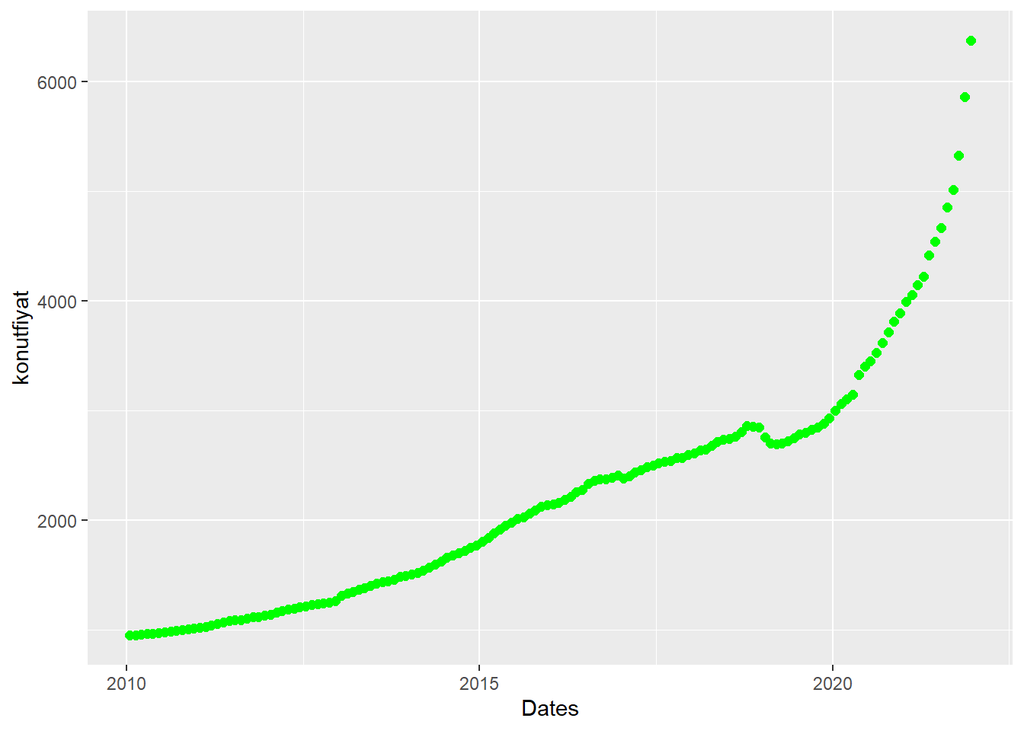

```r
ggplot(data=alldata)+geom_line(mapping=aes(x=Dates,y=konutfiyat),size=1,colour="00FF00")+
  geom_point(mapping=aes(x=Dates,y=konutfiyat),colour="#00FF00",size=2)
```

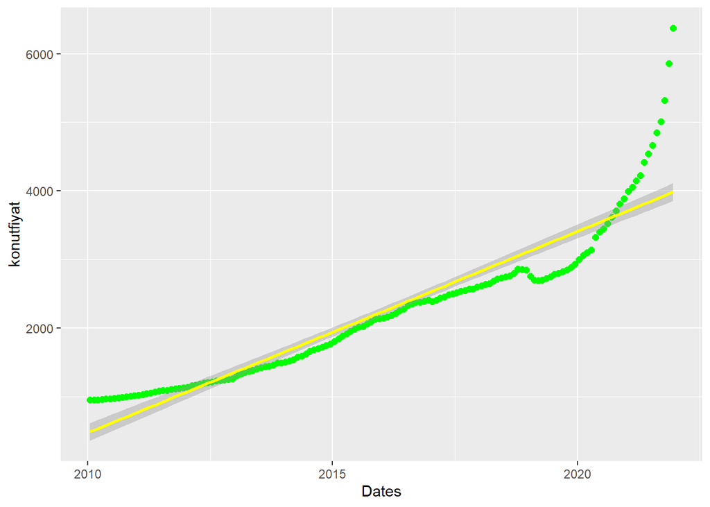

```r
  q <- ggplot(data=alldata)+geom_line(mapping=aes(x=Dates,y=konutfiyat),size=1,colour="00FF00")+
  geom_point(mapping=aes(x=Dates,y=konutfiyat),colour="#00FF00",size=2)
    q+   geom_smooth(mapping=aes(x=Dates,y=konutfiyat),method = lm, color = "yellow")
```